# Credit Card Fraud Detection

### Objetivo

Criar um modelo de classificacao que consiga identificar fraudes de cartoes de creditos.

### Compreensao dos dados

Este dataset contem transacoes historicas de cartoes de creditos. Contendo 284.807 transacoes e 492 fraudes detectadas.

O dataset possui apenas atributos numericos que por confidencialidade possuem nomes de V1, V2.. a V28, alem da variavel time e Amount.

O atriuto a ser previsto (Class) possui valores 0 e 1, sendo 0 para nao fraude e 1 para fraude.

**fonte dos dados: https://www.kaggle.com/mlg-ulb/creditcardfraud**

## Carregando os Modulos e Lendo os dados

```r
# carregando os modulos
library(tidyverse)
library(randomForest)
library(DMwR)
library(caret)
library(rpart)
library(rpart.plot)

# Lendo o conjunto de dados para treinamento
df <- read_csv("creditcard.csv", col_types = cols(.default = col_double(), Class = col_factor()))
```

## Analise Exploratoria

Visualização parcial do dataset

```r
# Visualizando as 5 primeiras e ultimas linhas dos dados
bind_rows(head(df),
          tail(df))
```

| Time | V1 | V2 | V3 | V4 | V5 | V6 | V7 | V8 | V9 | V10 | V11 | V12 | V13 | V14 | V15 | V16 | V17 | V18 | V19 | V20 | V21 | V22 | V23 | V24 | V25 | V26 | V27 | V28 | Amount | … |
| --- | --- | --- | --- | --- | --- | --- | --- | --- | --- | --- | --- | --- | --- | --- | --- | --- | --- | --- | --- | --- | --- | --- | --- | --- | --- | --- | --- | --- | --- | --- |
| 0 | -1.3598071 | -0.07278117 | 2.5363467 | 1.3781552 | -0.33832077 | 0.46238778 | 0.23959855 | 0.09869790 | 0.3637870 | 0.09079417 | -0.5515995 | -0.61780086 | -0.9913898 | -0.31116935 | 1.46817697 | -0.4704005 | 0.20797124 | 0.02579058 | 0.40399296 | 0.2514120982 | -0.018306778 | 0.277837576 | -0.11047391 | 0.066928075 | 0.1285394 | -0.1891148 | 0.133558377 | -0.02105305 | 149.62 | … |
| 0 | 1.1918571 | 0.26615071 | 0.1664801 | 0.4481541 | 0.06001765 | -0.08236081 | -0.07880298 | 0.08510165 | -0.2554251 | -0.16697441 | 1.6127267 | 1.06523531 | 0.4890950 | -0.14377230 | 0.63555809 | 0.4639170 | -0.11480466 | -0.18336127 | -0.14578304 | -0.0690831352 | -0.225775248 | -0.638671953 | 0.10128802 | -0.339846476 | 0.1671704 | 0.1258945 | -0.008983099 | 0.01472417 | 2.69 | … |
| 1 | -1.3583541 | -1.34016307 | 1.7732093 | 0.3797796 | -0.50319813 | 1.80049938 | 0.79146096 | 0.24767579 | -1.5146543 | 0.20764287 | 0.6245015 | 0.06608369 | 0.7172927 | -0.16594592 | 2.34586495 | -2.8900832 | 1.10996938 | -0.12135931 | -2.26185710 | 0.5249797252 | 0.247998153 | 0.771679402 | 0.90941226 | -0.689280956 | -0.3276418 | -0.1390966 | -0.055352794 | -0.05975184 | 378.66 | … |
| 1 | -0.9662717 | -0.18522601 | 1.7929933 | -0.8632913 | -0.01030888 | 1.24720317 | 0.23760894 | 0.37743587 | -1.3870241 | -0.05495192 | -0.2264873 | 0.17822823 | 0.5077569 | -0.28792375 | -0.63141812 | -1.0596472 | -0.68409279 | 1.96577500 | -1.23262197 | -0.2080377812 | -0.108300452 | 0.005273597 | -0.19032052 | -1.175575332 | 0.6473760 | -0.2219288 | 0.062722849 | 0.06145763 | 123.50 | … |
| 2 | -1.1582331 | 0.87773675 | 1.5487178 | 0.4030339 | -0.40719338 | 0.09592146 | 0.59294075 | -0.27053268 | 0.8177393 | 0.75307443 | -0.8228429 | 0.53819555 | 1.3458516 | -1.11966983 | 0.17512113 | -0.4514492 | -0.23703324 | -0.03819479 | 0.80348692 | 0.4085423604 | -0.009430697 | 0.798278495 | -0.13745808 | 0.141266984 | -0.2060096 | 0.5022922 | 0.219422230 | 0.21515315 | 69.99 | … |
| 2 | -0.4259659 | 0.96052304 | 1.1411093 | -0.1682521 | 0.42098688 | -0.02972755 | 0.47620095 | 0.26031433 | -0.5686714 | -0.37140720 | 1.3412620 | 0.35989384 | -0.3580907 | -0.13713370 | 0.51761681 | 0.4017259 | -0.05813282 | 0.06865315 | -0.03319379 | 0.0849676721 | -0.208253515 | -0.559824796 | -0.02639767 | -0.371426583 | -0.2327938 | 0.1059148 | 0.253844225 | 0.08108026 | 3.67 | … |
| 172785 | 0.1203164 | 0.93100513 | -0.5460121 | -0.7450968 | 1.13031398 | -0.23597317 | 0.81272207 | 0.11509285 | -0.2040635 | -0.65742212 | 0.6448373 | 0.19091623 | -0.5463289 | -0.73170658 | -0.80803553 | 0.5996281 | 0.07044075 | 0.37311030 | 0.12890379 | 0.0006758329 | -0.314204648 | -0.808520402 | 0.05034266 | 0.102799590 | -0.4358701 | 0.1240789 | 0.217939865 | 0.06880333 | 2.69 | … |
| 172786 | -11.8811179 | 10.07178497 | -9.8347835 | -2.0666557 | -5.36447278 | -2.60683733 | -4.91821543 | 7.30533402 | 1.9144283 | 4.35617041 | -1.5931053 | 2.71194079 | -0.6892556 | 4.62694203 | -0.92445871 | 1.1076406 | 1.99169111 | 0.51063233 | -0.68291968 | 1.4758291347 | 0.213454108 | 0.111863736 | 1.01447990 | -0.509348453 | 1.4368069 | 0.2500343 | 0.943651172 | 0.82373096 | 0.77 | … |
| 172787 | -0.7327887 | -0.05508049 | 2.0350297 | -0.7385886 | 0.86822940 | 1.05841527 | 0.02432970 | 0.29486870 | 0.5848000 | -0.97592606 | -0.1501888 | 0.91580191 | 1.2147558 | -0.67514296 | 1.16493091 | -0.7117573 | -0.02569286 | -1.22117886 | -1.54555609 | 0.0596158999 | 0.214205342 | 0.924383585 | 0.01246304 | -1.016225669 | -0.6066240 | -0.3952551 | 0.068472470 | -0.05352739 | 24.79 | … |
| 172788 | 1.9195650 | -0.30125385 | -3.2496398 | -0.5578281 | 2.63051512 | 3.03126010 | -0.29682653 | 0.70841718 | 0.4324540 | -0.48478176 | 0.4116137 | 0.06311886 | -0.1836987 | -0.51060184 | 1.32928351 | 0.1407160 | 0.31350179 | 0.39565248 | -0.57725184 | 0.0013959703 | 0.232045036 | 0.578229010 | -0.03750086 | 0.640133881 | 0.2657455 | -0.0873706 | 0.004454772 | -0.02656083 | 67.88 | … |

[output cut: 2 more lines]

Estrutura dos dados

```r
glimpse(df)
```

```
Observations: 284,807
Variables: 31
$ Time   <dbl> 0, 0, 1, 1, 2, 2, 4, 7, 7, 9, 10, 10, 10, 11, 12, 12, 12, 13, 14, 15, 16, 17, 18, 18, 22, 22, ...
$ V1     <dbl> -1.3598071, 1.1918571, -1.3583541, -0.9662717, -1.1582331, -0.4259659, 1.2296576, -0.6442694, ...
$ V2     <dbl> -0.07278117, 0.26615071, -1.34016307, -0.18522601, 0.87773675, 0.96052304, 0.14100351, 1.41796...
$ V3     <dbl> 2.53634674, 0.16648011, 1.77320934, 1.79299334, 1.54871785, 1.14110934, 0.04537077, 1.07438038...
$ V4     <dbl> 1.37815522, 0.44815408, 0.37977959, -0.86329128, 0.40303393, -0.16825208, 1.20261274, -0.49219...
$ V5     <dbl> -0.338320770, 0.060017649, -0.503198133, -0.010308880, -0.407193377, 0.420986881, 0.191880989,...
$ V6     <dbl> 0.46238778, -0.08236081, 1.80049938, 1.24720317, 0.09592146, -0.02972755, 0.27270812, 0.428118...
$ V7     <dbl> 0.239598554, -0.078802983, 0.791460956, 0.237608940, 0.592940745, 0.476200949, -0.005159003, 1...
$ V8     <dbl> 0.098697901, 0.085101655, 0.247675787, 0.377435875, -0.270532677, 0.260314333, 0.081212940, -3...
$ V9     <dbl> 0.3637870, -0.2554251, -1.5146543, -1.3870241, 0.8177393, -0.5686714, 0.4649600, 0.6153747, -0...
$ V10    <dbl> 0.09079417, -0.16697441, 0.20764287, -0.05495192, 0.75307443, -0.37140720, -0.09925432, 1.2493...
$ V11    <dbl> -0.55159953, 1.61272666, 0.62450146, -0.22648726, -0.82284288, 1.34126198, -1.41690724, -0.619...
$ V12    <dbl> -0.61780086, 1.06523531, 0.06608369, 0.17822823, 0.53819555, 0.35989384, -0.15382583, 0.291474...
```

[output cut: 18 more lines]

Estatistica descritiva dos dados

```r
summary(df)
```

```
      Time              V1                  V2                  V3                 V4
 Min.   :     0   Min.   :-56.40751   Min.   :-72.71573   Min.   :-48.3256   Min.   :-5.68317
 1st Qu.: 54202   1st Qu.: -0.92037   1st Qu.: -0.59855   1st Qu.: -0.8904   1st Qu.:-0.84864
 Median : 84692   Median :  0.01811   Median :  0.06549   Median :  0.1799   Median :-0.01985
 Mean   : 94814   Mean   :  0.00000   Mean   :  0.00000   Mean   :  0.0000   Mean   : 0.00000
 3rd Qu.:139321   3rd Qu.:  1.31564   3rd Qu.:  0.80372   3rd Qu.:  1.0272   3rd Qu.: 0.74334
 Max.   :172792   Max.   :  2.45493   Max.   : 22.05773   Max.   :  9.3826   Max.   :16.87534
       V5                   V6                 V7                 V8                  V9
 Min.   :-113.74331   Min.   :-26.1605   Min.   :-43.5572   Min.   :-73.21672   Min.   :-13.43407
 1st Qu.:  -0.69160   1st Qu.: -0.7683   1st Qu.: -0.5541   1st Qu.: -0.20863   1st Qu.: -0.64310
 Median :  -0.05434   Median : -0.2742   Median :  0.0401   Median :  0.02236   Median : -0.05143
 Mean   :   0.00000   Mean   :  0.0000   Mean   :  0.0000   Mean   :  0.00000   Mean   :  0.00000
 3rd Qu.:   0.61193   3rd Qu.:  0.3986   3rd Qu.:  0.5704   3rd Qu.:  0.32735   3rd Qu.:  0.59714
 Max.   :  34.80167   Max.   : 73.3016   Max.   :120.5895   Max.   : 20.00721   Max.   : 15.59500
      V10                 V11                V12                V13                V14
 Min.   :-24.58826   Min.   :-4.79747   Min.   :-18.6837   Min.   :-5.79188   Min.   :-19.2143
 1st Qu.: -0.53543   1st Qu.:-0.76249   1st Qu.: -0.4056   1st Qu.:-0.64854   1st Qu.: -0.4256
 Median : -0.09292   Median :-0.03276   Median :  0.1400   Median :-0.01357   Median :  0.0506
 Mean   :  0.00000   Mean   : 0.00000   Mean   :  0.0000   Mean   : 0.00000   Mean   :  0.0000
 3rd Qu.:  0.45392   3rd Qu.: 0.73959   3rd Qu.:  0.6182   3rd Qu.: 0.66251   3rd Qu.:  0.4931
 Max.   : 23.74514   Max.   :12.01891   Max.   :  7.8484   Max.   : 7.12688   Max.   : 10.5268
      V15                V16                 V17                 V18                 V19
 Min.   :-4.49894   Min.   :-14.12985   Min.   :-25.16280   Min.   :-9.498746   Min.   :-7.213527
 1st Qu.:-0.58288   1st Qu.: -0.46804   1st Qu.: -0.48375   1st Qu.:-0.498850   1st Qu.:-0.456299
 Median : 0.04807   Median :  0.06641   Median : -0.06568   Median :-0.003636   Median : 0.003735
 Mean   : 0.00000   Mean   :  0.00000   Mean   :  0.00000   Mean   : 0.000000   Mean   : 0.000000
 3rd Qu.: 0.64882   3rd Qu.:  0.52330   3rd Qu.:  0.39968   3rd Qu.: 0.500807   3rd Qu.: 0.458949
 Max.   : 8.87774   Max.   : 17.31511   Max.   :  9.25353   Max.   : 5.041069   Max.   : 5.591971
      V20                 V21                 V22                  V23                 V24
 Min.   :-54.49772   Min.   :-34.83038   Min.   :-10.933144   Min.   :-44.80774   Min.   :-2.83663
 1st Qu.: -0.21172   1st Qu.: -0.22839   1st Qu.: -0.542350   1st Qu.: -0.16185   1st Qu.:-0.35459
 Median : -0.06248   Median : -0.02945   Median :  0.006782   Median : -0.01119   Median : 0.04098
 Mean   :  0.00000   Mean   :  0.00000   Mean   :  0.000000   Mean   :  0.00000   Mean   : 0.00000
 3rd Qu.:  0.13304   3rd Qu.:  0.18638   3rd Qu.:  0.528554   3rd Qu.:  0.14764   3rd Qu.: 0.43953
 Max.   : 39.42090   Max.   : 27.20284   Max.   : 10.503090   Max.   : 22.52841   Max.   : 4.58455
      V25                 V26                V27                  V28                Amount         Class
 Min.   :-10.29540   Min.   :-2.60455   Min.   :-22.565679   Min.   :-15.43008   Min.   :    0.00   0:284315
 1st Qu.: -0.31715   1st Qu.:-0.32698   1st Qu.: -0.070840   1st Qu.: -0.05296   1st Qu.:    5.60   1:   492
 Median :  0.01659   Median :-0.05214   Median :  0.001342   Median :  0.01124   Median :   22.00
 Mean   :  0.00000   Mean   : 0.00000   Mean   :  0.000000   Mean   :  0.00000   Mean   :   88.35
 3rd Qu.:  0.35072   3rd Qu.: 0.24095   3rd Qu.:  0.091045   3rd Qu.:  0.07828   3rd Qu.:   77.17
 Max.   :  7.51959   Max.   : 3.51735   Max.   : 31.612198   Max.   : 33.84781   Max.   :25691.16
```

Grande parte do atributo class possuem apenas o valor zero.

Sera necessario balancear os dados para que o modelo consiga aprender o que seria fraude (1).

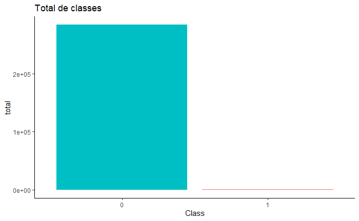

```r
# grafico de barras com o total por classe
df %>% group_by(Class) %>%
  summarise(total = n()) %>%
  ggplot(aes(x = Class, y = total, fill = as.factor(total))) +
  geom_bar(stat = "identity", show.legend = F) +
  theme_classic() +
  ggtitle("Total de classes")
```

Conforme o novo grafico, os atributos estao bem mais equilibrados.

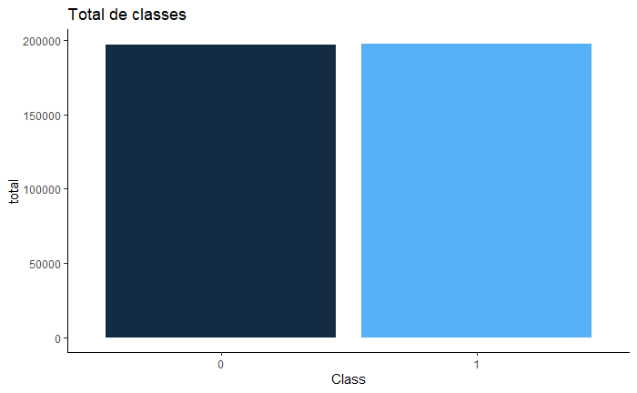

```r
# Novo dataset com os dados balanceados
df_smote <- SMOTE(Class ~., as.data.frame(df), perc.over = 40000, perc.under = 100) %>% as_tibble()

# grafico de barras com o total por classe
df_smote %>% group_by(Class) %>%
  summarise(total = n()) %>%
  ggplot(aes(x = Class, y = total, fill = total)) +
  geom_bar(stat = "identity", show.legend = F) +
  theme_classic() +
  ggtitle("Total de classes")
```

## Criando o modelo

Criando dois datasets, um com 70% dos dados para criar o modelo e o outro com 30% dos dados para usar como teste.

```r
# Dividindo os dados em treino e teste (70/30)
set.seed(124)
index <- createDataPartition(df_smote$Class, p = 0.7, list = FALSE)
train <- df_smote[index,-1]
test <- df_smote[-index,-1]
```

Como forma de ilustracao, a funcao “rpart” ira criar uma arvore de decisao com os atributos escolhidos ao acaso, V1, V2 e V3.

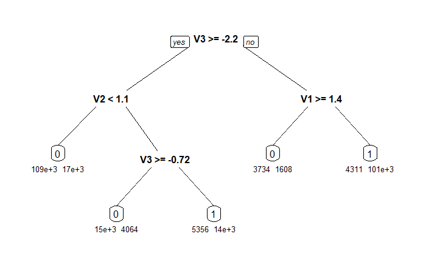

```r
# Criando um modelo bom base em uma arvore de decisao
model_dt <- rpart(Class ~ V1 + V2 + V3,
                     data = train,
                     method = "class")

# Plotando a arvore
prp(model_dt, type = 0, extra = 1, under = TRUE, compress = TRUE)
```

O modelo Random Forest foi criado utilizando todos os atributos dos dados de treino e 50 arvores.

Aparentemente o modelo esta com overfitting, pois a taxa de erro esta proxima de 0% mediante aos dados de treino.

```r
# Criando um modelo com random forest para 50 arvores
model_rf <- randomForest(Class ~., data = train, ntree = 50)

# resumo do modelo
model_rf
```

```
Call:
 randomForest(formula = Class ~ ., data = train, ntree = 50)
               Type of random forest: classification
                     Number of trees: 50
No. of variables tried at each split: 5

        OOB estimate of  error rate: 0.02%
Confusion matrix:
       0      1  class.error
0 137708     52 3.774681e-04
1      5 138100 3.620434e-05
```

## Feature Selection

Uma vantagem do random forest, seria a visualizacao das importancia dos atributos, permitindo que seja possivel selecionar os atributos que mais impactam no resutlado do modelo, sendo uma forma de reduzir o overfitting.

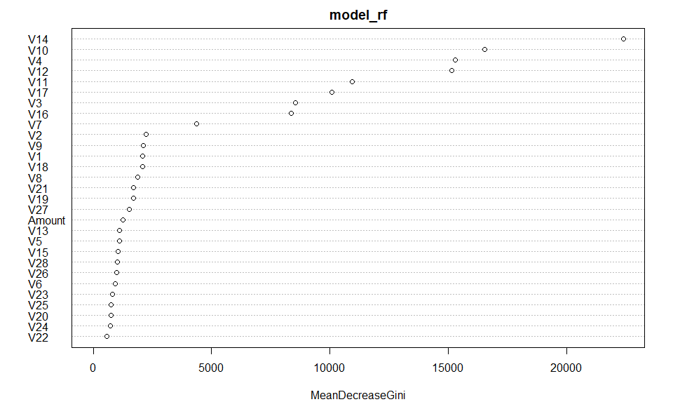

```r
# Selecao de atributos
varImpPlot(model_rf)
```

Criando um novo modelo de Random Forest com os atributos selecionados

```r
# Criando um modelo com random forest para 50 arvores
model_rf <- randomForest(Class ~ V14 + V10 + V12 + V4 + V17, data = train, ntree = 50)
```

## Avaliando o modelo

Apos a criacao do novo modelo, ele sera testado com dados que nao participaram da criacao do modelo, de forma a validar sua capacidade de generalizacao.

A acuracia final foi de 99%.

```r
# Prevendo os dados de teste
pred_rf <- predict(model_rf, test)

# Matriz de confusao
confusionMatrix(test$Class, pred_rf)
```

```
Confusion Matrix and Statistics

          Reference
Prediction     0     1
         0 58858   182
         1   219 58968

               Accuracy : 0.9966
                 95% CI : (0.9963, 0.9969)
    No Information Rate : 0.5003
    P-Value [Acc > NIR] : < 2e-16

                  Kappa : 0.9932

 Mcnemar's Test P-Value : 0.07222

            Sensitivity : 0.9963
            Specificity : 0.9969
         Pos Pred Value : 0.9969
         Neg Pred Value : 0.9963
             Prevalence : 0.4997
         Detection Rate : 0.4978
   Detection Prevalence : 0.4994
      Balanced Accuracy : 0.9966

       'Positive' Class : 0
```